# Evaluation Project - 9 Zomato Restaurant Project

Zomato Data Analysis is one of the most useful analysis for foodies who want to taste the best

cuisines of every part of the world which lies in their budget. This analysis is also for those who

want to find the value for money restaurants in various parts of the country for the cuisines.

Additionally, this analysis caters the needs of people who are striving to get the best cuisine of

the country and which locality of that country serves that cuisines with maximum number of

restaurants.

**Data Storage:**

This problem statement contains two datasets- **Zomato.csv** and **country_code.csv.**

**Country_code.csv** contains two variables:

 Country code

 Country name

The collected data has been stored in the Comma Separated Value file **Zomato.csv**. Each

restaurant in the dataset is uniquely identified by its Restaurant Id. Every Restaurant contains the

following variables:

• Restaurant Id: Unique id of every restaurant across various cities of the world

• Restaurant Name: Name of the restaurant

• Country Code: Country in which restaurant is located

• City: City in which restaurant is located

• Address: Address of the restaurant

• Locality: Location in the city

• Locality Verbose: Detailed description of the locality

• Longitude: Longitude coordinate of the restaurant&#39;s location

• Latitude: Latitude coordinate of the restaurant&#39;s location

• Cuisines: Cuisines offered by the restaurant

• Currency: Currency of the country

• Has Table booking: yes/no

• Has Online delivery: yes/ no

• Is delivering: yes/ no

• Switch to order menu: yes/no

• Price range: range of price of food

• Aggregate Rating: Average rating out of 5

• Rating color: depending upon the average rating color

• Rating text: text on the basis of rating of rating

• Votes: Number of ratings casted by people

**Problem statement : In this dataset predict 2 things –**

1) Average Cost for two

2) Price range

**Hint :** Use pandas merge operation -- pd.merge (df1,df2) to combine two datasets

```python
import numpy as np
import pandas as pd
import matplotlib.pyplot as plt
import plotly.express as px
import seaborn as sns
import cufflinks as cf
cf.go_offline()
import warnings
warnings.filterwarnings('ignore')
```

```python
#loading dataset
df1= pd.read_csv('zomato.csv', encoding='latin1')
```

```python
df1=df1[df1['Country Code'].isin([1])].reset_index()
```

```python
df1.drop(['index'], axis=1)
```

|  | Restaurant ID | Restaurant Name | Country Code | City | Address | Locality | Locality Verbose | Longitude | Latitude | Cuisines | ... | Currency | Has Table booking | Has Online delivery | Is delivering now | Switch to order menu | Price range | Aggregate rating | Rating color | Rating text | Votes |
| --- | --- | --- | --- | --- | --- | --- | --- | --- | --- | --- | --- | --- | --- | --- | --- | --- | --- | --- | --- | --- | --- |
| 0 | 3400025 | Jahanpanah | 1 | Agra | E 23, Shopping Arcade, Sadar Bazaar, Agra Cant... | Agra Cantt | Agra Cantt, Agra | 78.011544 | 27.161661 | North Indian, Mughlai | ... | Indian Rupees(Rs.) | No | No | No | No | 3 | 3.9 | Yellow | Good | 140 |
| 1 | 3400341 | Rangrezz Restaurant | 1 | Agra | E-20, Shopping Arcade, Sadar Bazaar, Agra Cant... | Agra Cantt | Agra Cantt, Agra | 0.000000 | 0.000000 | North Indian, Mughlai | ... | Indian Rupees(Rs.) | No | No | No | No | 2 | 3.5 | Yellow | Good | 71 |
| 2 | 3400005 | Time2Eat - Mama Chicken | 1 | Agra | Main Market, Sadar Bazaar, Agra Cantt, Agra | Agra Cantt | Agra Cantt, Agra | 78.011608 | 27.160832 | North Indian | ... | Indian Rupees(Rs.) | No | No | No | No | 2 | 3.6 | Yellow | Good | 94 |
| 3 | 3400021 | Chokho Jeeman Marwari Jain Bhojanalya | 1 | Agra | 1/48, Delhi Gate, Station Road, Raja Mandi, Ci... | Civil Lines | Civil Lines, Agra | 77.998092 | 27.195928 | Rajasthani | ... | Indian Rupees(Rs.) | No | No | No | No | 2 | 4.0 | Green | Very Good | 87 |
| 4 | 3400017 | Pinch Of Spice | 1 | Agra | 23/453, Opposite Sanjay Cinema, Wazipura Road,... | Civil Lines | Civil Lines, Agra | 78.007553 | 27.201725 | North Indian, Chinese, Mughlai | ... | Indian Rupees(Rs.) | No | No | No | No | 3 | 4.2 | Green | Very Good | 177 |
| ... | ... | ... | ... | ... | ... | ... | ... | ... | ... | ... | ... | ... | ... | ... | ... | ... | ... | ... | ... | ... | ... |
| 8647 | 2800100 | D Cabana | 1 | Vizag | Beach Road, Near Bus Stop, Sagar Nagar, Visakh... | Sagar Nagar | Sagar Nagar, Vizag | 83.361377 | 17.764287 | Continental, Seafood, Chinese, North Indian, B... | ... | Indian Rupees(Rs.) | No | No | No | No | 2 | 3.6 | Yellow | Good | 193 |
| 8648 | 2800418 | Kaloreez | 1 | Vizag | Plot 95, Opposite St. Lukes Nursing School, Da... | Siripuram | Siripuram, Vizag | 0.000000 | 0.000000 | Cafe, North Indian, Chinese | ... | Indian Rupees(Rs.) | No | No | No | No | 2 | 3.7 | Yellow | Good | 85 |
| 8649 | 2800881 | Plot 17 | 1 | Vizag | Plot 17, Gangapur Layout, Siripuram, Vizag | Siripuram | Siripuram, Vizag | 83.315281 | 17.719539 | Burger, Pizza, Biryani | ... | Indian Rupees(Rs.) | No | No | No | No | 2 | 4.3 | Green | Very Good | 172 |
| 8650 | 2800042 | Vista - The Park | 1 | Vizag | The Park, Beach Road, Pedda Waltair, Lawsons B... | The Park, Lawsons Bay | The Park, Lawsons Bay, Vizag | 83.336840 | 17.721182 | American, North Indian, Thai, Continental | ... | Indian Rupees(Rs.) | No | No | No | No | 4 | 3.8 | Yellow | Good | 74 |
| 8651 | 2800019 | Flying Spaghetti Monster | 1 | Vizag | 10-50-12/F2, Sai Dakshata Complex, Beside Leno... | Waltair Uplands | Waltair Uplands, Vizag | 83.314942 | 17.721119 | Italian | ... | Indian Rupees(Rs.) | No | No | No | No | 3 | 4.4 | Green | Very Good | 316 |

8652 rows × 21 columns

```python
df1['City'].unique()
```

```
array(['Agra', 'Ahmedabad', 'Allahabad', 'Amritsar', 'Aurangabad',
       'Bangalore', 'Bhopal', 'Bhubaneshwar', 'Chandigarh', 'Chennai',
       'Coimbatore', 'Dehradun', 'Faridabad', 'Ghaziabad', 'Goa',
       'Gurgaon', 'Guwahati', 'Hyderabad', 'Indore', 'Jaipur', 'Kanpur',
       'Kochi', 'Kolkata', 'Lucknow', 'Ludhiana', 'Mangalore', 'Mohali',
       'Mumbai', 'Mysore', 'Nagpur', 'Nashik', 'New Delhi', 'Noida',
       'Panchkula', 'Patna', 'Puducherry', 'Pune', 'Ranchi',
       'Secunderabad', 'Surat', 'Vadodara', 'Varanasi', 'Vizag'],
      dtype=object)
```

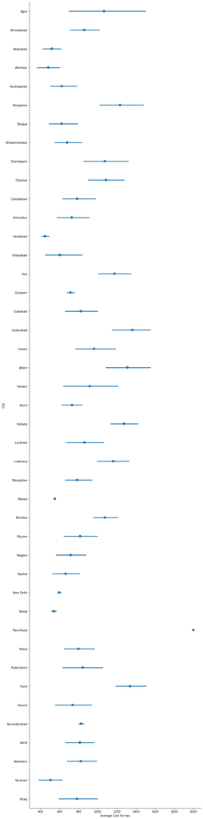

```python
sns.factorplot(x="Average Cost for two",y='City',data=df1,size=40,aspect =0.25, join= False)
```

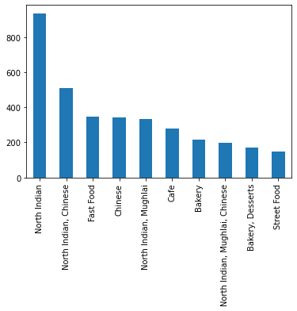

```python
df1['Cuisines'].value_counts()[:10].plot(kind='bar')
```

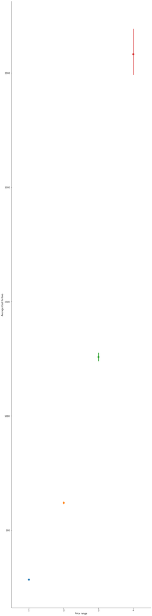

```python
sns.factorplot(x="Price range",y='Average Cost for two',hue='Price range',data=df1,size=40,aspect =0.25, join= False)
```

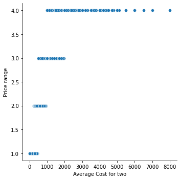

```python
sns.relplot(x = 'Average Cost for two', y = 'Price range', data= df1, )
plt.show()
```

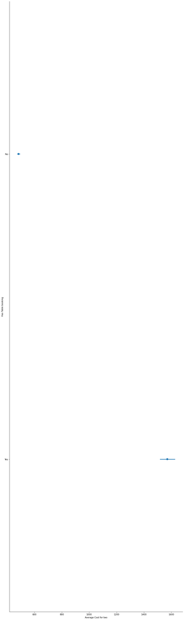

```python
sns.factorplot(x="Average Cost for two",y='Has Table booking',data=df1,size=40,aspect =0.3, join= False)
```

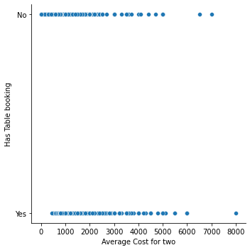

```python
sns.relplot(x = 'Average Cost for two', y = 'Has Table booking', data= df1, )
plt.show()
```

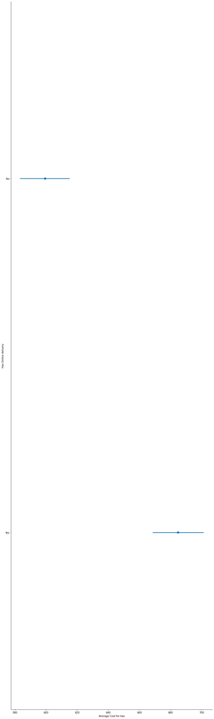

```python
sns.factorplot(x="Average Cost for two",y='Has Online delivery',data=df1,size=40,aspect =0.3, join= False)
```

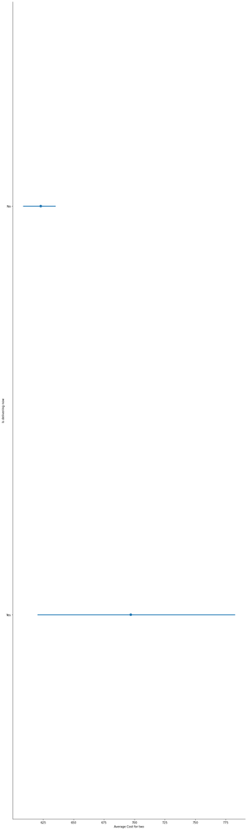

```python
sns.factorplot(x="Average Cost for two",y='Is delivering now',data=df1,size=40,aspect =0.3, join= False)
```

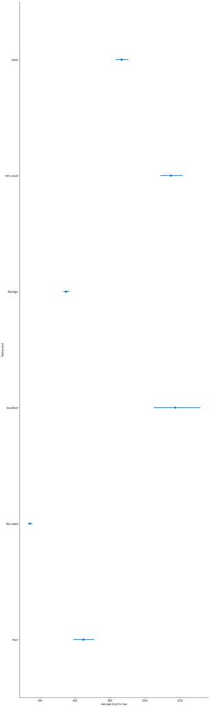

```python
sns.factorplot(x="Average Cost for two",y='Rating text',data=df1,size=40,aspect =0.3, join= False)
```

```python
# Deleting those columns which are not useful in predictive analysis because these variables are qualitative
UselessColumns = [
                'Restaurant ID', 'Restaurant Name','Address','Country Code',
                'Locality', 'Locality Verbose','Cuisines','Longitude','Latitude',
                'Currency','Votes',
                "Aggregate rating","Switch to order menu",'Rating color'
                ]
ZomatoData = df1.drop(UselessColumns,axis=1)
ZomatoData.head().reset_index(inplace=True)
```

```python
ZomatoData.drop(['index'], axis=1,inplace=True)
```

```python
from sklearn.preprocessing import LabelEncoder
le=LabelEncoder()
df13=le.fit_transform(ZomatoData['City'])
pd.Series(df13)
ZomatoData['City']=df13
```

```python
from sklearn.preprocessing import LabelEncoder
le=LabelEncoder()
df13=le.fit_transform(ZomatoData['Has Table booking'])
pd.Series(df13)
ZomatoData['Has Table booking']=df13
```

```python
from sklearn.preprocessing import LabelEncoder
le=LabelEncoder()
df13=le.fit_transform(ZomatoData['Has Online delivery'])
pd.Series(df13)
ZomatoData['Has Online delivery']=df13
```

```python
from sklearn.preprocessing import LabelEncoder
le=LabelEncoder()
df13=le.fit_transform(ZomatoData['Is delivering now'])
pd.Series(df13)
ZomatoData['Is delivering now']=df13
```

```python
from sklearn.preprocessing import LabelEncoder
le=LabelEncoder()
df13=le.fit_transform(ZomatoData['Rating text'])
pd.Series(df13)
ZomatoData['Rating text']=df13
```

```python
ZomatoData
```

|  | City | Average Cost for two | Has Table booking | Has Online delivery | Is delivering now | Price range | Rating text |
| --- | --- | --- | --- | --- | --- | --- | --- |
| 0 | 0 | 850 | 0 | 0 | 0 | 3 | 2 |
| 1 | 0 | 700 | 0 | 0 | 0 | 2 | 2 |
| 2 | 0 | 500 | 0 | 0 | 0 | 2 | 2 |
| 3 | 0 | 400 | 0 | 0 | 0 | 2 | 5 |
| 4 | 0 | 1000 | 0 | 0 | 0 | 3 | 5 |
| ... | ... | ... | ... | ... | ... | ... | ... |
| 8647 | 42 | 600 | 0 | 0 | 0 | 2 | 2 |
| 8648 | 42 | 400 | 0 | 0 | 0 | 2 | 2 |
| 8649 | 42 | 600 | 0 | 0 | 0 | 2 | 5 |
| 8650 | 42 | 1500 | 0 | 0 | 0 | 4 | 2 |
| 8651 | 42 | 1400 | 0 | 0 | 0 | 3 | 5 |

8652 rows × 7 columns

```python
f = ZomatoData.drop('Average Cost for two', axis=1)
l = ZomatoData['Average Cost for two']
```

```python
from sklearn.model_selection import train_test_split
```

```python
from sklearn.preprocessing import StandardScaler

scalar = StandardScaler()
X_scalar=scalar.fit_transform(f)
```

```python
from sklearn.model_selection import train_test_split
```

```python
# Split data into train and test. Model will be built on training data and tested on test data.
x_train,x_test,y_train,y_test= train_test_split (X_scalar, l, test_size =0.25, random_state=348)
y_train.head()
```

```
1775    1200
3466     200
1964     300
1162     250
1165     450
Name: Average Cost for two, dtype: int64
```

```python
ZomatoData.tail (2)
```

|  | City | Average Cost for two | Has Table booking | Has Online delivery | Is delivering now | Price range | Rating text |
| --- | --- | --- | --- | --- | --- | --- | --- |
| 8650 | 42 | 1500 | 0 | 0 | 0 | 4 | 2 |
| 8651 | 42 | 1400 | 0 | 0 | 0 | 3 | 5 |

```python
# Since we have already fit the scaler, you can transform the data
print ('Predicted Average Cost for two',regression.predict (scalar.transform ([[42, 0, 0, 0, 3, 5]])))
```

```
Predicted Average Cost for two [1300.41281902]
```

```python
f
```

|  | City | Has Table booking | Has Online delivery | Is delivering now | Price range | Rating text |
| --- | --- | --- | --- | --- | --- | --- |
| 0 | 0 | 0 | 0 | 0 | 3 | 2 |
| 1 | 0 | 0 | 0 | 0 | 2 | 2 |
| 2 | 0 | 0 | 0 | 0 | 2 | 2 |
| 3 | 0 | 0 | 0 | 0 | 2 | 5 |
| 4 | 0 | 0 | 0 | 0 | 3 | 5 |
| ... | ... | ... | ... | ... | ... | ... |
| 8647 | 42 | 0 | 0 | 0 | 2 | 2 |
| 8648 | 42 | 0 | 0 | 0 | 2 | 2 |
| 8649 | 42 | 0 | 0 | 0 | 2 | 5 |
| 8650 | 42 | 0 | 0 | 0 | 4 | 2 |
| 8651 | 42 | 0 | 0 | 0 | 3 | 5 |

8652 rows × 6 columns

```python
from sklearn.model_selection import train_test_split
from sklearn.metrics import r2_score,mean_squared_error,mean_absolute_error
from sklearn.linear_model import RANSACRegressor
from sklearn.linear_model import Ridge,Lasso,ElasticNet
from sklearn.preprocessing import PolynomialFeatures
from sklearn.linear_model import SGDRegressor
from sklearn.ensemble import RandomForestRegressor
from sklearn.model_selection import cross_val_score
from sklearn.model_selection import GridSearchCV
from sklearn.svm import SVR
import warnings
warnings.filterwarnings('ignore')
maxAccu=0
lrm=LinearRegression()
maxRS=0
for i in range(1,200):
    x_train,x_test,y_train,y_test=train_test_split(f,l,test_size=0.25,random_state=i)
    lrm = LinearRegression()
    lrm.fit(x_train, y_train)
    pred=lrm.predict(x_test)
    acc=r2_score(y_test,pred)
    if acc>maxAccu:
        maxAccu=acc
        maxRS=i
print('the best accuracy is ',maxAccu,'on random state',maxRS)
```

```
the best accuracy is  0.7867991977296173 on random state 40
```

```python
x_train,x_test,y_train,y_test=train_test_split(f,l,test_size=0.25,random_state=40)
```

```python
#Let's check how well model fits on train data
# Adjusted R2 score # .score is nothing but Adjusted R2 score
# when we have multiple feature that time we check Adjusted R2 score
lrm.score (x_train,y_train)
```

```
0.7136325901321554
```

```python
#Let's check how well model fits the test data.
lrm.score(x_test,y_test)
```

```
0.7896927095977921
```

```python
y_pred = lrm.predict(x_test)
```

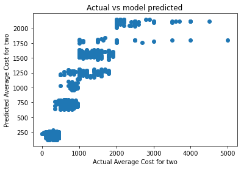

```python
plt.scatter (y_test,y_pred)
plt.xlabel('Actual Average Cost for two')
plt.ylabel('Predicted Average Cost for two')
plt.title('Actual vs model predicted')
plt.show()
```

```python
from sklearn.metrics import mean_squared_error, mean_absolute_error
```

```python
y_pred = regression.predict(x_test)
```

```python
#MAE
mean_absolute_error(y_test,y_pred)
```

```
1258.452807255739
```

```python
#MSE
mean_squared_error(y_test,y_pred)
```

```
1636214.9248281503
```

```python
#RMSE
np.sqrt(mean_squared_error(y_test,y_pred))
```

```
1279.1461702355014
```

```python
from sklearn.linear_model import Ridge, Lasso, RidgeCV, LassoCV
```

```python
# LassoCV will return best alpha after max iteration
# Normalize is subtracting the mean and dividing by the L2-norm
lasscv = LassoCV (alphas = None, max_iter = 100, normalize = True) # normalize is similer to standerized the data
lasscv.fit(x_train, y_train)
```

```
LassoCV(max_iter=100, normalize=True)
```

```python
# best alpha parameter/best learning rate
alpha= lasscv.alpha_
alpha
```

```
0.00633317105936785
```

```python
lasso_reg = Lasso (alpha)
lasso_reg. fit (x_train, y_train)
```

```
Lasso(alpha=0.00633317105936785)
```

```python
lasso_reg.score(x_test,y_test)
```

```
0.7868058793413384
```

```python
ridgecv=RidgeCV (alphas = np.arange (0.001,0.1,0.01), normalize = True)
ridgecv.fit(x_train, y_train)
```

```
RidgeCV(alphas=array([0.001, 0.011, 0.021, 0.031, 0.041, 0.051, 0.061, 0.071, 0.081,
       0.091]),
        normalize=True)
```

```python
ridgecv.alpha_
```

```
0.001
```

```python
ridge_model= Ridge(alpha=ridgecv.alpha_)
ridge_model.fit(x_train, y_train)
```

```
Ridge(alpha=0.001)
```

```python
ridge_model.score(x_test, y_test)
```

```
0.7867992392159116
```

```python
# Conlussion We got around same r2 square using Ridge regression as well. So, it's safe to say there is no overfitting.

# lasso_reg.scor ~ ridge_model.score ~ regression.score
# So, we can see by using different type of regularization, we still are getting the same r2 score. That means our OLS model has been well trained over the training data and there is no overfitting. In the real time we dont built one model we bulit multiple model interms of which model is going to give best accuracy that model we are goint to pick
```

# EDA major highlights

```python
#loading dataset
d1= pd.read_csv('zomato.csv', encoding='latin1')
```

```python
d2= pd.read_excel('Country-Code.xlsx')
```

```python
#merge function to merge both CSV and XSL file
# Use pandas merge operation -- pd.merge (df1,df2) to combine two datasets
```

```python
#merge function to merge both CSV and XSL files
d = pd.merge(d1,d2,on='Country Code',how='left')   #left join focusing on the left (csv dataset)
```

```python
# until now we have grab some basic information about the data set
# Now we are making some questions and will try to find out the answer
# Q1) How many  Country are in our dataset
#A1--> 15 Country
# Q2) Which Country maximum number of transactions happen
#A2---> India
# Q3 Which are the top 3 countries with maximum number of orders
#A3-->India (with maximum), USA and then UK.
#Q4 Which city Has maximum number Restaurant listed on zomato
```

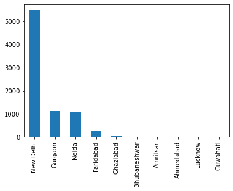

```python
d['City'].value_counts()[:10].plot(kind='bar')
```

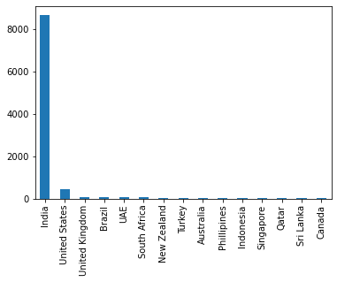

```python
#displaying the total number of records based on country
data=d.Country.value_counts()
d.Country.value_counts().plot(kind='bar')
```

```python
## From this we can summarize that the maximum number of transactions happen in India
## As Zomato is a startup from India hence it makes sense that it has maximum business spread across restaurants in India.
```

```python
px.bar(d,x = data.index , y = data.values,text=data.index,color = data.index,text_auto=True,title="total number of records based on country")
```

[interactive chart not shown]

```python
# top 3 countries with maximum number of orders are India (with maximum), USA and then UK.
```

```python
# Lets check  how many  countries in our data set
```

```python
d.Country.unique()
```

```
array(['Phillipines', 'Brazil', 'United States', 'Australia', 'Canada',
       'Singapore', 'UAE', 'India', 'Indonesia', 'New Zealand',
       'United Kingdom', 'Qatar', 'South Africa', 'Sri Lanka', 'Turkey'],
      dtype=object)
```

```python
## The total number country is 15.
```

```python
#displaying the ratings related columns in a dataframe format

d.groupby(['Aggregate rating','Rating color','Rating text']).size().reset_index()
```

|  | Aggregate rating | Rating color | Rating text | 0 |
| --- | --- | --- | --- | --- |
| 0 | 0.0 | White | Not rated | 2148 |
| 1 | 1.8 | Red | Poor | 1 |
| 2 | 1.9 | Red | Poor | 2 |
| 3 | 2.0 | Red | Poor | 7 |
| 4 | 2.1 | Red | Poor | 15 |
| 5 | 2.2 | Red | Poor | 27 |
| 6 | 2.3 | Red | Poor | 47 |
| 7 | 2.4 | Red | Poor | 87 |
| 8 | 2.5 | Orange | Average | 110 |
| 9 | 2.6 | Orange | Average | 191 |
| 10 | 2.7 | Orange | Average | 250 |
| 11 | 2.8 | Orange | Average | 315 |
| 12 | 2.9 | Orange | Average | 381 |
| 13 | 3.0 | Orange | Average | 468 |
| 14 | 3.1 | Orange | Average | 519 |
| 15 | 3.2 | Orange | Average | 522 |
| 16 | 3.3 | Orange | Average | 483 |
| 17 | 3.4 | Orange | Average | 498 |
| 18 | 3.5 | Yellow | Good | 480 |
| 19 | 3.6 | Yellow | Good | 458 |
| 20 | 3.7 | Yellow | Good | 427 |
| 21 | 3.8 | Yellow | Good | 400 |
| 22 | 3.9 | Yellow | Good | 335 |
| 23 | 4.0 | Green | Very Good | 266 |
| 24 | 4.1 | Green | Very Good | 274 |
| 25 | 4.2 | Green | Very Good | 221 |
| 26 | 4.3 | Green | Very Good | 174 |
| 27 | 4.4 | Green | Very Good | 144 |
| 28 | 4.5 | Dark Green | Excellent | 95 |
| 29 | 4.6 | Dark Green | Excellent | 78 |
| 30 | 4.7 | Dark Green | Excellent | 42 |
| 31 | 4.8 | Dark Green | Excellent | 25 |
| 32 | 4.9 | Dark Green | Excellent | 61 |

```python
ratings = d.groupby(['Aggregate rating','Rating color','Rating text']).size().reset_index().rename(columns={0:'Rating Count'})
ratings
```

|  | Aggregate rating | Rating color | Rating text | Rating Count |
| --- | --- | --- | --- | --- |
| 0 | 0.0 | White | Not rated | 2148 |
| 1 | 1.8 | Red | Poor | 1 |
| 2 | 1.9 | Red | Poor | 2 |
| 3 | 2.0 | Red | Poor | 7 |
| 4 | 2.1 | Red | Poor | 15 |
| 5 | 2.2 | Red | Poor | 27 |
| 6 | 2.3 | Red | Poor | 47 |
| 7 | 2.4 | Red | Poor | 87 |
| 8 | 2.5 | Orange | Average | 110 |
| 9 | 2.6 | Orange | Average | 191 |
| 10 | 2.7 | Orange | Average | 250 |
| 11 | 2.8 | Orange | Average | 315 |
| 12 | 2.9 | Orange | Average | 381 |
| 13 | 3.0 | Orange | Average | 468 |
| 14 | 3.1 | Orange | Average | 519 |
| 15 | 3.2 | Orange | Average | 522 |
| 16 | 3.3 | Orange | Average | 483 |
| 17 | 3.4 | Orange | Average | 498 |
| 18 | 3.5 | Yellow | Good | 480 |
| 19 | 3.6 | Yellow | Good | 458 |
| 20 | 3.7 | Yellow | Good | 427 |
| 21 | 3.8 | Yellow | Good | 400 |
| 22 | 3.9 | Yellow | Good | 335 |
| 23 | 4.0 | Green | Very Good | 266 |
| 24 | 4.1 | Green | Very Good | 274 |
| 25 | 4.2 | Green | Very Good | 221 |
| 26 | 4.3 | Green | Very Good | 174 |
| 27 | 4.4 | Green | Very Good | 144 |
| 28 | 4.5 | Dark Green | Excellent | 95 |
| 29 | 4.6 | Dark Green | Excellent | 78 |
| 30 | 4.7 | Dark Green | Excellent | 42 |
| 31 | 4.8 | Dark Green | Excellent | 25 |
| 32 | 4.9 | Dark Green | Excellent | 61 |

```python
px.bar(ratings,x = "Aggregate rating" , y = "Rating text",color = "Rating text",text_auto=True,)
```

[interactive chart not shown]

```python
px.bar(ratings,x = "Aggregate rating" , y = "Rating Count",color = "Rating text",text_auto=True,)
```

[interactive chart not shown]